# Защита лабораторной работе №5

Операционные системы

Обрезкова Анастасия Владимировна, НММбд-02-22

Российский университет дружбы народов, Москва, Россия

# Информация

## Докладчик

- Обрезкова Анастасия Владимировна
- студентка направления “Математика и механика”
- Российский университет дружбы народов
- 1132226505@pfur.ru

# Вводная часть

## Цель работы

Ознакомление с файловой системой Linux, её структурой, именами и содержанием каталогов. Приобретение практических навыков по применению команд для работы с файлами и каталогами, по управлению процессами (и работами), по проверке использования диска и обслуживанию файловой системы.

# Основная часть

## Выполнение лабораторной работы

- Выполнила все примеры, приведённые в первой части описания лабораторной работы

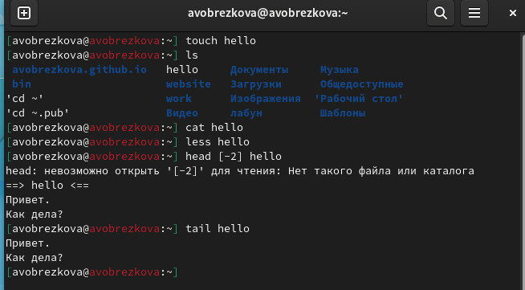

Первая часть

## Этап 2

- Скопировала файл /usr/include/sys/io.h в домашний каталог и назовите его equipment.

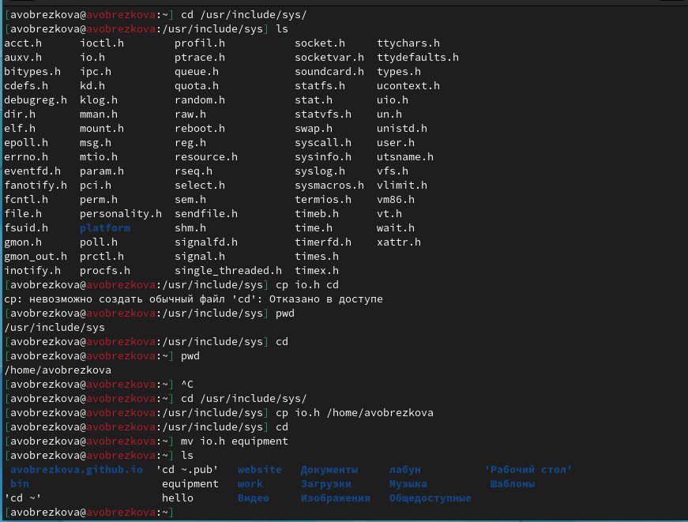

## Этап 2

- В домашнем каталоге создала директорию ~/ski.plases.

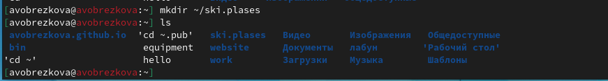

- Переместила файл equipment в каталог ~/ski.plases.

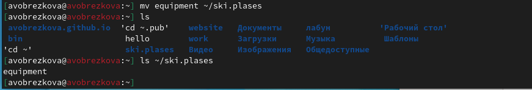

## Этап 2

- Переименовала файл ~/ski.plases/equipment в ~/ski.plases/equiplist.

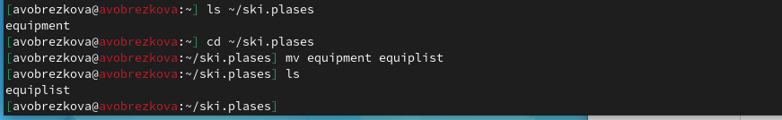

- Создала в домашнем каталоге файл abc1 и скопировала его в каталог ~/ski.plases, назвала его equiplist2.

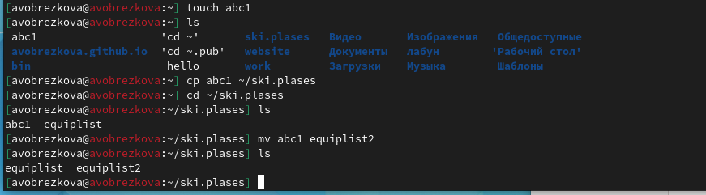

## Этап 2

- Создаем каталог с именем equipment в каталоге ~/ski.plases.

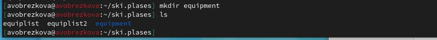

- Переместила файлы ~/ski.plases/equiplist и equiplist2 в каталог ~/ski.plases/equipment.

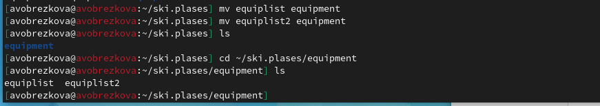

## Этап 2

- Создала и переместила каталог ~/newdir в каталог ~/ski.plases и назвала его plans.

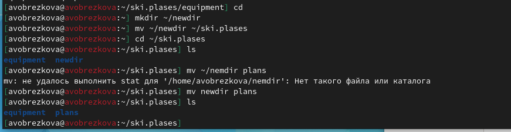

## Этап 3

- Определите опции команды chmod, необходимые для того, чтобы присвоить перечисленным ниже файлам выделенные права доступа.
- С помощью команды chmod файлу australia присвоила нужные права доступа.

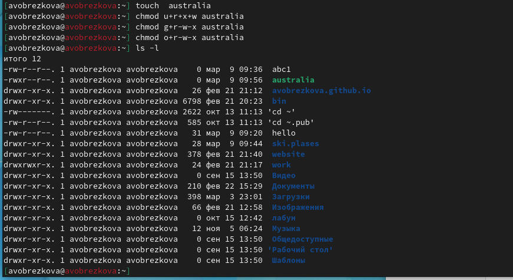

## Этап 3

- С помощью команды chmod файлу play присвоила нужные права доступа.

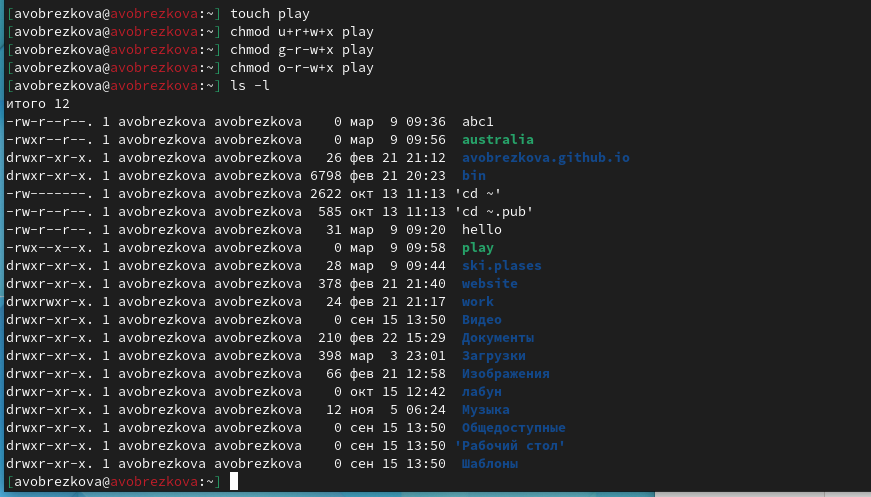

## Этап 3

- С помощью команды chmod файлу my_os присвоила нужные права доступа.

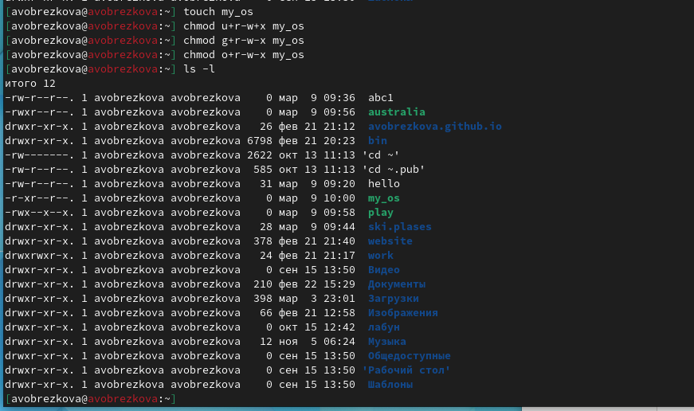

## Этап 3

- С помощью команды chmod файлу feathers присвоила нужные права доступа.

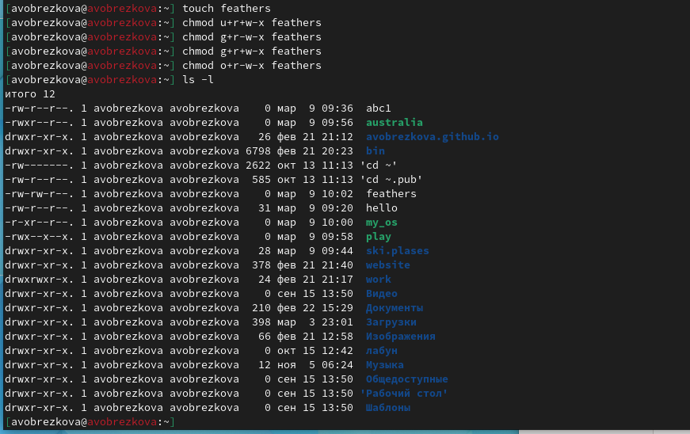

## Этап 4

- Просмотрела содержимое файла /etc/password.

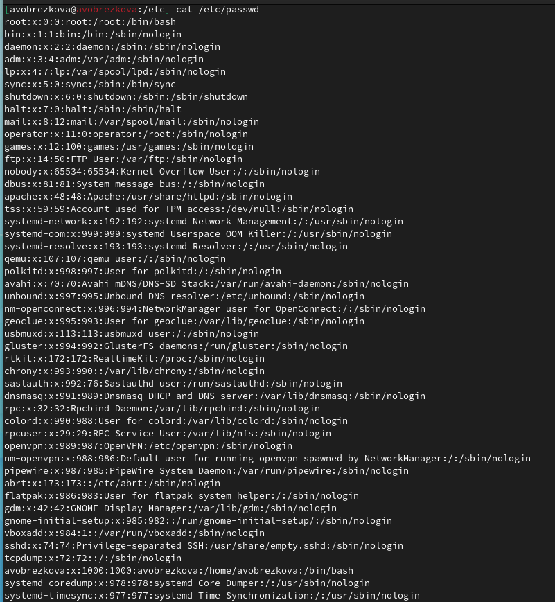

## Этап 4

- Скопировала файл ~/feathers в файл ~/file.old.

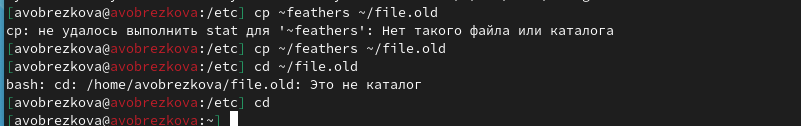

- Переместила файл ~/file.old в каталог ~/play.

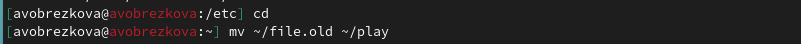

- Скопировала каталог ~/play в каталог ~/fun.

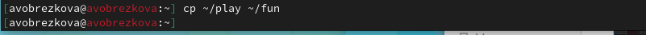

## Этап 4

- Переместила каталог ~/fun в каталог ~/play и назвала его games.

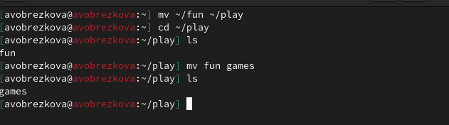

## Этап 4

- Лишила владельца файла ~/feathers права на чтение.

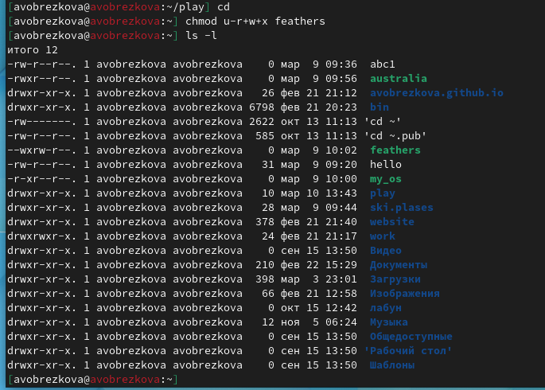

## Этап 4

- Я попыталась просмотреть файл ~/feathers командой cat, мне было отказано в доступе, так как файл был лишен права на чтение.

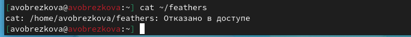

- Когда я попыталась скопировать файл ~/feathers, мне было отказано в доступе, так как файл лишен права на чтение.

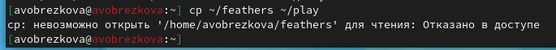

## Этап 4

- Дала владельцу файла ~/feathers право на чтение.

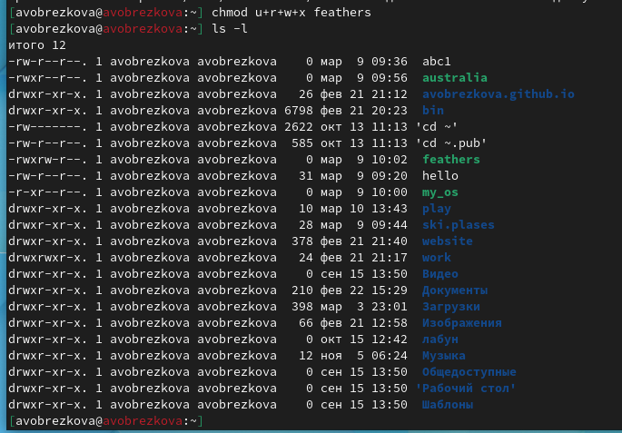

## Этап 4

- Лишила владельца каталога ~/play права на выполнение.

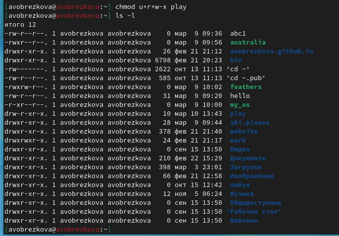

## Этап 4

- Перешла в каталог ~/play. Увидела, что мне отказано в доступе, так как нет права на выполнение.

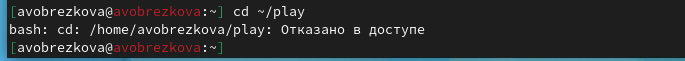

## Этап 5

-Используя команды «man mount», «man fsck», «man mkfs», «man kill», получим информацию о соответствующих командах:

- Команда mount: предназначена для монтирования файловой системы. Все файлы, доступные в Unix системах, составляют иерархическую файловую структуру, которая имеет ветки (каталоги) и листья (файлы в каталогах). Корень этого дерева обозначается как /. Физически файлы могут располагаться на различных устройствах. Команда mount служит для подключения файловых систем разных устройств к этому большому дереву.

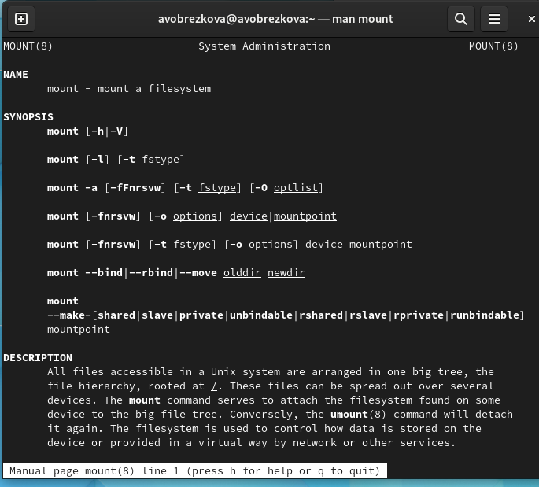

## Этап 5

- Команда fsck: это утилита командной строки, которая позволяет выполнять проверки согласованности и интерактивное исправление в одной или нескольких файловых системах Linux. Он использует программы, специфичные для типа файловой системы, которую он проверяет. У команды fsck следующий синтаксис: fsck [параметр] – [параметры ФС] [<файловая система> . . .] Например, если нужно восстановить («починить») файловую систему на некотором устройстве /dev/sdb2, следует воспользоваться командой: «sudo fsck -y /dev/sdb2»

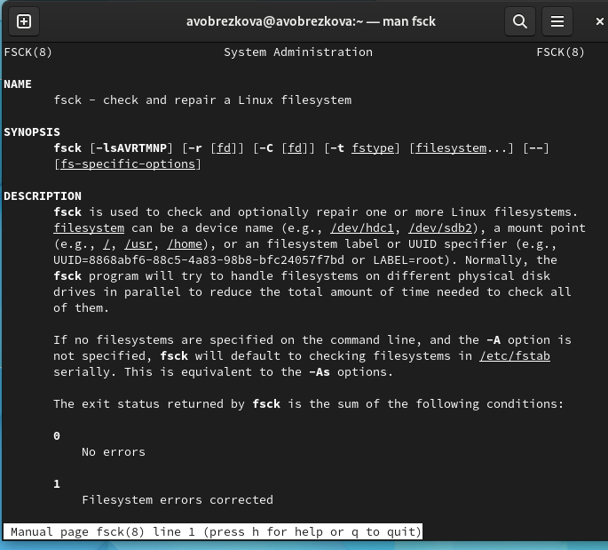

## Этап 5

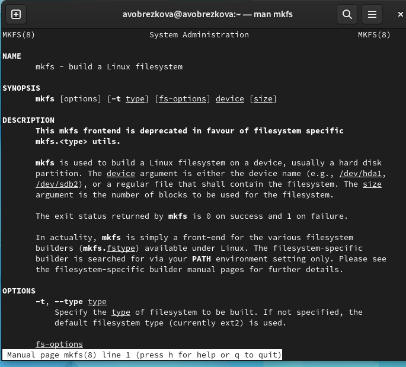

## Этап 5

- Команда kill: посылает сигнал процессу или выводит список допустимых сигналов. Имеет следующий синтаксис: kill [опции] PID, где PID – это PID (числовой идентификатор) процесса или несколько PID процессов, если требуется послать сигнал сразу нескольким процессам. Например, команда «kill -KILL 3121» посылает сигнал KILL процессу с PID 3121, чтобы принудительно завершить процесс

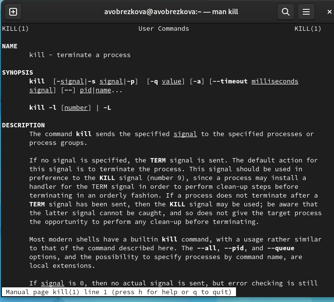

# Заключение

## Вывод

В ходе выполнения данной лабораторной работы я ознакомилась с файловой системой Linux, её структурой, именами и содержанием каталогов, получила навыки по применению команд для работы с файлами и каталогами, по управлению процессами (и работами), по проверке использования диска и обслуживанию файловой системы.